# Introduction

This dataset collects information from 100k medical appointments in Brazil and is focused on the question of whether or not patients show up for their appointment. A number of characteristics about the patient are included in each row.

‘ScheduledDay’ tells us on what day the patient set up their appointment. ‘Neighborhood’ indicates the location of the hospital. ‘Scholarship’ indicates whether or not the patient is enrolled in Brasilian welfare program Bolsa Família. Be careful about the encoding of the last column: it says ‘No’ if the patient showed up to their appointment, and ‘Yes’ if they did not show up.

from this database we can solve many questions like that:

*Can Gender effect on visit?

*Does Age effect on visit?

*what about neighbourhood?

*what about scholarship?

*what about hipertension?

*what about Diabetes?

*what about Alcoholism?

*what about Handcap?

*what about Sms_received?

# Imports

```python
import numpy as np
import pandas as pd
import matplotlib.pyplot as plt
import seaborn as sns
```

# Loading Data

```python
df = pd.read_csv("noshowappointments-kagglev2-may-2016.csv")
df.head()
```

|  | PatientId | AppointmentID | Gender | ScheduledDay | AppointmentDay | Age | Neighbourhood | Scholarship | Hipertension | Diabetes | Alcoholism | Handcap | SMS_received | No-show |
| --- | --- | --- | --- | --- | --- | --- | --- | --- | --- | --- | --- | --- | --- | --- |
| 0 | 2.987250e+13 | 5642903 | F | 2016-04-29T18:38:08Z | 2016-04-29T00:00:00Z | 62 | JARDIM DA PENHA | 0 | 1 | 0 | 0 | 0 | 0 | No |
| 1 | 5.589978e+14 | 5642503 | M | 2016-04-29T16:08:27Z | 2016-04-29T00:00:00Z | 56 | JARDIM DA PENHA | 0 | 0 | 0 | 0 | 0 | 0 | No |
| 2 | 4.262962e+12 | 5642549 | F | 2016-04-29T16:19:04Z | 2016-04-29T00:00:00Z | 62 | MATA DA PRAIA | 0 | 0 | 0 | 0 | 0 | 0 | No |
| 3 | 8.679512e+11 | 5642828 | F | 2016-04-29T17:29:31Z | 2016-04-29T00:00:00Z | 8 | PONTAL DE CAMBURI | 0 | 0 | 0 | 0 | 0 | 0 | No |
| 4 | 8.841186e+12 | 5642494 | F | 2016-04-29T16:07:23Z | 2016-04-29T00:00:00Z | 56 | JARDIM DA PENHA | 0 | 1 | 1 | 0 | 0 | 0 | No |

```python
df.shape
```

```
(110527, 14)
```

```python
df.info()
```

```
<class 'pandas.core.frame.DataFrame'>
RangeIndex: 110527 entries, 0 to 110526
Data columns (total 14 columns):
 #   Column          Non-Null Count   Dtype
---  ------          --------------   -----
 0   PatientId       110527 non-null  float64
 1   AppointmentID   110527 non-null  int64
 2   Gender          110527 non-null  object
 3   ScheduledDay    110527 non-null  object
 4   AppointmentDay  110527 non-null  object
 5   Age             110527 non-null  int64
 6   Neighbourhood   110527 non-null  object
 7   Scholarship     110527 non-null  int64
 8   Hipertension    110527 non-null  int64
 9   Diabetes        110527 non-null  int64
 10  Alcoholism      110527 non-null  int64
 11  Handcap         110527 non-null  int64
 12  SMS_received    110527 non-null  int64
 13  No-show         110527 non-null  object
dtypes: float64(1), int64(8), object(5)
memory usage: 11.8+ MB
```

in data types the date or day of scheduled or appointment should be datetime not object

```python
sum(df.duplicated())
```

```
0
```

No Data Duplicates

```python
df.isnull().sum()
```

```
PatientId         0
AppointmentID     0
Gender            0
ScheduledDay      0
AppointmentDay    0
Age               0
Neighbourhood     0
Scholarship       0
Hipertension      0
Diabetes          0
Alcoholism        0
Handcap           0
SMS_received      0
No-show           0
dtype: int64
```

No Data Missing

# Data Cleaning

```python
df.AppointmentDay = pd.to_datetime(df.AppointmentDay)
df.ScheduledDay = pd.to_datetime(df.ScheduledDay)
```

```python
df.info()
```

```
<class 'pandas.core.frame.DataFrame'>
RangeIndex: 110527 entries, 0 to 110526
Data columns (total 14 columns):
 #   Column          Non-Null Count   Dtype
---  ------          --------------   -----
 0   PatientId       110527 non-null  float64
 1   AppointmentID   110527 non-null  int64
 2   Gender          110527 non-null  object
 3   ScheduledDay    110527 non-null  datetime64[ns, UTC]
 4   AppointmentDay  110527 non-null  datetime64[ns, UTC]
 5   Age             110527 non-null  int64
 6   Neighbourhood   110527 non-null  object
 7   Scholarship     110527 non-null  int64
 8   Hipertension    110527 non-null  int64
 9   Diabetes        110527 non-null  int64
 10  Alcoholism      110527 non-null  int64
 11  Handcap         110527 non-null  int64
 12  SMS_received    110527 non-null  int64
 13  No-show         110527 non-null  object
dtypes: datetime64[ns, UTC](2), float64(1), int64(8), object(3)
memory usage: 11.8+ MB
```

```python
df.drop(["ScheduledDay","AppointmentDay","PatientId","AppointmentID"] , axis = 1 , inplace = True)
```

```python
df.head()
```

|  | Gender | Age | Neighbourhood | Scholarship | Hipertension | Diabetes | Alcoholism | Handcap | SMS_received | No-show |
| --- | --- | --- | --- | --- | --- | --- | --- | --- | --- | --- |
| 0 | F | 62 | JARDIM DA PENHA | 0 | 1 | 0 | 0 | 0 | 0 | No |
| 1 | M | 56 | JARDIM DA PENHA | 0 | 0 | 0 | 0 | 0 | 0 | No |
| 2 | F | 62 | MATA DA PRAIA | 0 | 0 | 0 | 0 | 0 | 0 | No |
| 3 | F | 8 | PONTAL DE CAMBURI | 0 | 0 | 0 | 0 | 0 | 0 | No |
| 4 | F | 56 | JARDIM DA PENHA | 0 | 1 | 1 | 0 | 0 | 0 | No |

```python
df = df.rename(columns ={ "No-show" : "Noshow"} )
```

changing No-show name to Noshow to easiest for reading and writing

# Exploratory Data Analysis

```python
df.Noshow.value_counts()
```

```
No     88208
Yes    22319
Name: Noshow, dtype: int64
```

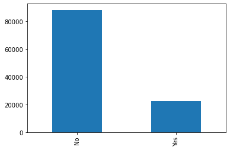

```python
df.Noshow.value_counts().plot(kind = "bar")
```

more than 80000 patients are attended and more than 20000 patients aren't attended

```python
#function for avoiding repetition of code
def display_plot(df,col,title,xlabel):
    x = sns.countplot(x = df[col] ,hue = df.Noshow,data =df)
    x.set_title(title)
    x.set_xticklabels(xlabel)
    return plt.show()
```

# Can Gender effect on visit?

```python
df.Gender.unique()
```

```
array(['F', 'M'], dtype=object)
```

```python
df.Gender.value_counts()
```

```
F    71840
M    38687
Name: Gender, dtype: int64
```

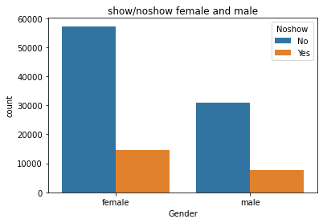

```python
display_plot(df,"Gender","show/noshow female and male",["female" , "male"])
```

Gender Is Insignificant

# Does Age effect on visit?

```python
np.sort(df.Age.unique())
```

```
array([ -1,   0,   1,   2,   3,   4,   5,   6,   7,   8,   9,  10,  11,
        12,  13,  14,  15,  16,  17,  18,  19,  20,  21,  22,  23,  24,
        25,  26,  27,  28,  29,  30,  31,  32,  33,  34,  35,  36,  37,
        38,  39,  40,  41,  42,  43,  44,  45,  46,  47,  48,  49,  50,
        51,  52,  53,  54,  55,  56,  57,  58,  59,  60,  61,  62,  63,
        64,  65,  66,  67,  68,  69,  70,  71,  72,  73,  74,  75,  76,
        77,  78,  79,  80,  81,  82,  83,  84,  85,  86,  87,  88,  89,
        90,  91,  92,  93,  94,  95,  96,  97,  98,  99, 100, 102, 115],
      dtype=int64)
```

```python
df = df.query("Age >= 0")
```

```python
df.shape
```

```
(110526, 10)
```

```
<function matplotlib.pyplot.show(close=None, block=None)>
```

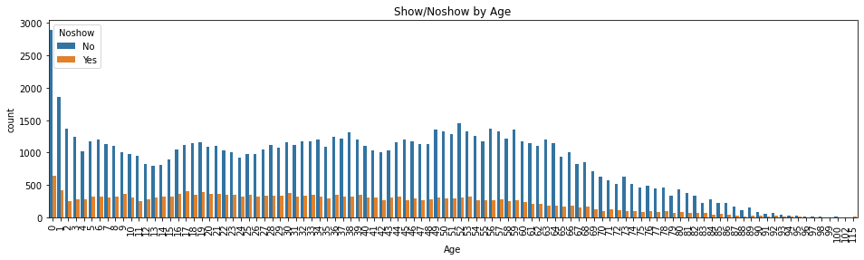

```python
plt.figure(figsize=(16,4))
plt.xticks(rotation = 90)
x = sns.countplot(x = df.Age , hue = df.Noshow , data = df)
x.set_title("Show/Noshow by Age")
plt.show
```

Age is significant

the patients between 0 to 10 years is most attend and followed by the patients between 35 to 70

the older people who has less attend to their appointment

# what about neighbourhood?

```
<function matplotlib.pyplot.show(close=None, block=None)>
```

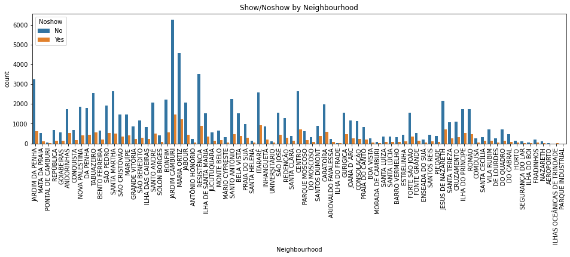

```python
plt.figure(figsize=(16,4))
plt.xticks(rotation = 90)
x = sns.countplot(x = df.Neighbourhood , hue = df.Noshow , data = df)
x.set_title("Show/Noshow by Neighbourhood")
plt.show
```

Neighbourhood is totally significant , it's really affecting on showing people at the clinic

# what about scholarship?

```python
df.Scholarship.value_counts()
```

```
0    99665
1    10861
Name: Scholarship, dtype: int64
```

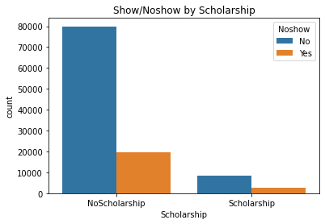

```python
display_plot(df,"Scholarship","Show/Noshow by Scholarship",["NoScholarship" , "Scholarship"])
```

Scholarship Is Insignificant

# what about hipertension?

```python
df.Hipertension.value_counts()
```

```
0    88726
1    21801
Name: Hipertension, dtype: int64
```

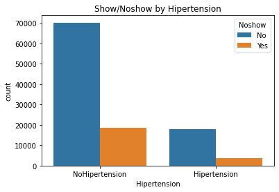

```python
display_plot(df,"Hipertension","Show/Noshow by Hipertension",["NoHipertension" , "Hipertension"])
```

Hipertension Is Insignificant

# what about Diabetes?

```python
df.Diabetes.value_counts()
```

```
0    102584
1      7943
Name: Diabetes, dtype: int64
```

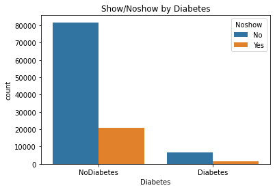

```python
display_plot(df,"Diabetes","Show/Noshow by Diabetes",["NoDiabetes" , "Diabetes"])
```

Diabetes Is Insignificant

# what about Alcoholism?

```python
df.Alcoholism.value_counts()
```

```
0    107167
1      3360
Name: Alcoholism, dtype: int64
```

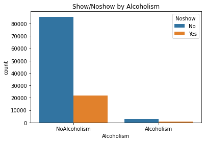

```python
display_plot(df,"Alcoholism","Show/Noshow by Alcoholism",["NoAlcoholism" , "Alcoholism"])
```

Alcoholism is Insignificant

# what about Handcap?

```python
df.Handcap.value_counts()
```

```
0    108286
1      2042
2       183
3        13
4         3
Name: Handcap, dtype: int64
```

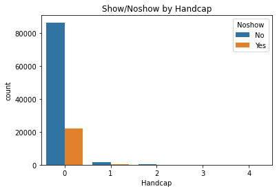

```python
display_plot(df,"Handcap","Show/Noshow by Handcap",["0","1","2","3","4"])
```

Handcap is Insignificant

# what about Sms_received?

```python
df.SMS_received.value_counts()
```

```
0    75045
1    35482
Name: SMS_received, dtype: int64
```

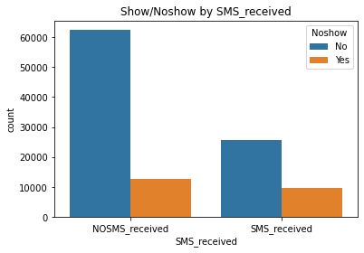

```python
display_plot(df,"SMS_received","Show/Noshow by SMS_received",["NOSMS_received" , "SMS_received"])
```

SMS_received is significant

# Conclusions

Finally we can say the significant factors or features on this data

Neighbourhood is strongly related to the patients attendance to the clinic

Age also has the same effect , the patients between 0 to 10 years is most attend and followed by the patients between 35 to 70

at the end of them the Sms_received

# Limitations :

can't find strong correlations between showing patients and many factors like Gender , diseases and disabilities